# Práctica VAR

Azael Carrillo Cabrera

Profesor: Dr. Gustavo Cabrera González

```r
library(ggplot2)
library(ggthemes)
library(scales)
library(reshape2)
library(dplyr)
library(readxl)
library(knitr)
library(kableExtra)
```

### Extraemos los datos y los preparamos:

```r
btc <- read_excel("ex_parcial1_bitcoin_MCMC (3).xlsx",
                  col_types = c("date", "numeric", "numeric"))
btc$Time<- as.POSIXct(btc$Time, format="%m/%d/%Y %I:%M:%S%p")
colnames(btc)[1] <- "time"
btc = btc %>%
  mutate(cre.price = 100*(price-lag(price))/lag(price), cre.volume = 100*(volume-lag(volume))/lag(volume))
btc = btc %>%
  mutate(cre.priceL1 = lag(cre.price), cre.priceL2 = lag(cre.price, n = 2), cre.priceL3 = lag(cre.price, n = 3), cre.priceL4 = lag(cre.price, n = 4), cre.priceL5 = lag(cre.price, n = 5), cre.volumeL1 = lag(cre.volume, n = 1), cre.volumeL2 = lag(cre.volume, n = 2), cre.volumeL3 = lag(cre.volume, n = 3), cre.volumeL4 = lag(cre.volume, n = 4), cre.volumeL5 = lag(cre.volume, n = 5))
kable(head(btc, 7) ,escape = F) %>%
  kable_styling("hover", full_width = F) %>%
  column_spec(1, width = "2cm")
```

| time | price | volume | cre.price | cre.volume | cre.priceL1 | cre.priceL2 | cre.priceL3 | cre.priceL4 | cre.priceL5 | cre.volumeL1 | cre.volumeL2 | cre.volumeL3 | cre.volumeL4 | cre.volumeL5 |
| --- | --- | --- | --- | --- | --- | --- | --- | --- | --- | --- | --- | --- | --- | --- |
| 2017-01-02 01:00:00 | 983.7185 | 837794794 | NA | NA | NA | NA | NA | NA | NA | NA | NA | NA | NA | NA |
| 2017-01-09 01:00:00 | 840.8095 | 465750160 | -14.527420 | -44.40761 | NA | NA | NA | NA | NA | NA | NA | NA | NA | NA |
| 2017-01-16 01:00:00 | 888.9537 | 355846682 | 5.725931 | -23.59709 | -14.527420 | NA | NA | NA | NA | -44.40761 | NA | NA | NA | NA |
| 2017-01-23 01:00:00 | 913.2138 | 214222614 | 2.729065 | -39.79918 | 5.725931 | -14.527420 | NA | NA | NA | -23.59709 | -44.40761 | NA | NA | NA |
| 2017-01-30 01:00:00 | 982.5541 | 337245736 | 7.592987 | 57.42770 | 2.729065 | 5.725931 | -14.527420 | NA | NA | -39.79918 | -23.59709 | -44.40761 | NA | NA |
| 2017-02-06 01:00:00 | 1019.3037 | 444133570 | 3.740219 | 31.69435 | 7.592987 | 2.729065 | 5.725931 | -14.527420 | NA | 57.42770 | -39.79918 | -23.59709 | -44.40761 | NA |
| 2017-02-13 01:00:00 | 1029.4092 | 272733749 | 0.991412 | -38.59195 | 3.740219 | 7.592987 | 2.729065 | 5.725931 | -14.52742 | 31.69435 | 57.42770 | -39.79918 | -23.59709 | -44.40761 |

## Primera Parte

### Sistema de dos ecuciones endógenas

$y_1:Volumen(\%)$  
$y_2:Precio (rendimiento\ \%)$  
$y_{1t}=c_1+\beta_{11}y_{1t-1}+\beta_{12}y_{2t-1}+\epsilon_{1t}$  
$y_{2t}=c_2+\beta_{21}y_{1t-1}+\beta_{22}y_{2t-1}+\epsilon_{2t}$

### 1) Estimación individual, ecuación por ecuación

```r
fit1 <- lm(cre.volume ~ cre.volumeL1 + cre.priceL1, data = btc)
fit2 <- lm(cre.price ~ cre.volumeL1 + cre.priceL1, btc)
summary(fit1)
```

```
Call:
lm(formula = cre.volume ~ cre.volumeL1 + cre.priceL1, data = btc)

Residuals:
   Min     1Q Median     3Q    Max
-61.06 -25.64 -10.59  17.31 116.03

Coefficients:
             Estimate Std. Error t value Pr(>|t|)
(Intercept)    7.1157     4.1437   1.717  0.08954 .
cre.volumeL1  -0.2954     0.1053  -2.806  0.00621 **
cre.priceL1    1.2522     0.3982   3.145  0.00228 **
---
Signif. codes:  0 ‘***’ 0.001 ‘**’ 0.01 ‘*’ 0.05 ‘.’ 0.1 ‘ ’ 1

Residual standard error: 37.64 on 86 degrees of freedom
  (2 observations deleted due to missingness)
Multiple R-squared:  0.1351,    Adjusted R-squared:  0.115
F-statistic: 6.718 on 2 and 86 DF,  p-value: 0.001945
```

```r
summary(fit2)
```

```
Call:
lm(formula = cre.price ~ cre.volumeL1 + cre.priceL1, data = btc)

Residuals:
     Min       1Q   Median       3Q      Max
-18.5145  -7.2281   0.5835   6.4552  25.7809

Coefficients:
             Estimate Std. Error t value Pr(>|t|)
(Intercept)  1.770197   1.071456   1.652 0.102152
cre.volumeL1 0.006317   0.027227   0.232 0.817077
cre.priceL1  0.386344   0.102955   3.753 0.000317 ***
---
Signif. codes:  0 ‘***’ 0.001 ‘**’ 0.01 ‘*’ 0.05 ‘.’ 0.1 ‘ ’ 1

Residual standard error: 9.733 on 86 degrees of freedom
  (2 observations deleted due to missingness)
Multiple R-squared:  0.1606,    Adjusted R-squared:  0.1411
F-statistic: 8.226 on 2 and 86 DF,  p-value: 0.0005381
```

### 2) Quién afecta a quién?

$H0:\beta_{12}=0$  
Vemos que $\beta_{12}$ sí es significativo. Es decir, el cambio porcentual del precio del periodo anterior sí afecta el volumen $H0:\beta_{21}=0$  
Por otro lado, $\beta_{21}$ no es significativo por si solo; el cambio porcentual del volumen del periodo anterior no afecta al precio

### 3) Respuesta a los shocks

```r
sum1 <- summary(fit1)
varFit1 <- sum1$sigma
##varFit1 <- sqrt(mean(sum1$residuals^2))
sum2 <- summary(fit2)
varFit2 <- sum2$sigma
##varFit2 <- sqrt(mean(sum2$residuals^2))
```

#### a) Shocks del volumen

$y_{1T+1}= \sigma_1, y_{2T+1}=0$

```r
shockSig <- data.frame(volE = varFit1, priE = 0, volE2 = 0, priE2 = varFit2, index = 1)
no <- 9
for (i in 1:no) {
shockSig[i+1, "volE"] <- sum1$coefficients["(Intercept)", 1] + sum1$coefficients["cre.volumeL1", 1]*shockSig$volE[i] + sum1$coefficients["cre.priceL1", 1]*shockSig$priE[i]
shockSig[i+1, "priE"] <- sum2$coefficients["(Intercept)", 1] + sum2$coefficients["cre.volumeL1", 1]*shockSig$volE[i] + sum2$coefficients["cre.priceL1", 1]*shockSig$priE[i]
shockSig$index[i+1] <-i+1
}
```

#### b) Shocks del precio

$y_{1T+1}= 0, y_{2T+1}=\sigma_2$

```r
for (i in 1:no) {
shockSig[i+1, "volE2"] <- sum1$coefficients["(Intercept)", 1] + sum1$coefficients["cre.volumeL1", 1]*shockSig$volE2[i] + sum1$coefficients["cre.priceL1", 1]*shockSig$priE2[i]
shockSig[i+1, "priE2"] <- sum2$coefficients["(Intercept)", 1] + sum2$coefficients["cre.volumeL1", 1]*shockSig$volE2[i] + sum2$coefficients["cre.priceL1", 1]*shockSig$priE2[i]
}
```

#### Tabla de respuestas a los shocks

```r
  kable(shockSig, escape = F) %>%
  kable_styling("hover", full_width = F) %>%
  column_spec(5, width = "4cm") %>%
  add_header_above(c("Shocks Volumen" = 2, "Shocks Precio" = 2, ""))
```

| Shocks Volumen volE | Shocks Volumen priE | Shocks Precio volE2 | Shocks Precio priE2 | index |
| --- | --- | --- | --- | --- |
| 37.640544 | 0.000000 | 0.000000 | 9.732928 | 1 |
| -4.004785 | 2.007980 | 19.302825 | 5.530456 | 2 |
| 10.813152 | 2.520669 | 8.337877 | 4.028796 | 3 |
| 7.077331 | 2.812352 | 9.697032 | 3.379371 | 4 |
| 8.546268 | 2.901442 | 8.482304 | 3.137055 | 5 |
| 8.223842 | 2.945140 | 8.537764 | 3.035764 | 6 |
| 8.373817 | 2.959986 | 8.394547 | 2.996982 | 7 |
| 8.348098 | 2.966670 | 8.388297 | 2.981093 | 8 |
| 8.364064 | 2.969089 | 8.370249 | 2.974915 | 9 |
| 8.362377 | 2.970125 | 8.367845 | 2.972415 | 10 |

### 4) Grafica los 4 resultados anteriors y analiza cuál efecto cruzado es mayor?

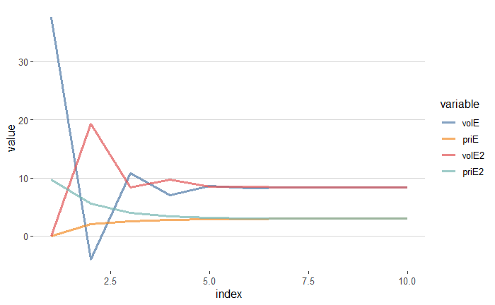

```r
shSMelt <- melt(shockSig[,1:5], id.vars = "index")
ggplot(shSMelt, aes(x = index, y = value, color = variable))+
  geom_line(size=1.1, alpha=0.7)+
  scale_color_tableau("Tableau 10")+
  theme_hc()+
  theme(legend.position = "right")
```

### 5) Repite el 3 y 4

#### a)$y_{1T+1}= 1, y_{2T+1}= 0$

```r
shocks1 <- data.frame(volE = 1, priE = 0, volE2 = 0, priE2 = 1, index = 1)
no <- 9
for (i in 1:no) {
shocks1[i+1, "volE"] <- sum1$coeff["(Intercept)", 1] + sum1$coeff["cre.volumeL1", 1]*shocks1$volE[i] + sum1$coeff["cre.priceL1", 1]*shocks1$priE[i]
shocks1[i+1, "priE"] <- sum2$coeff["(Intercept)", 1] + sum2$coeff["cre.volumeL1", 1]*shocks1$volE[i] + sum2$coeff["cre.priceL1", 1]*shocks1$priE[i]
shocks1$index[i+1] <-i+1
}
```

```r
for (i in 1:no) {
shocks1[i+1, "volE2"] <- sum1$coeff["(Intercept)", 1] + sum1$coeff["cre.volumeL1", 1]*shocks1$volE2[i] + sum1$coeff["cre.priceL1", 1]*shocks1$priE2[i]
shocks1[i+1, "priE2"] <- sum2$coeff["(Intercept)", 1] + sum2$coeff["cre.volumeL1", 1]*shocks1$volE2[i] + sum2$coeff["cre.priceL1", 1]*shocks1$priE2[i]
}
```

#### Tabla de respuestas a los shocks

```r
  kable(shocks1, escape = F) %>%
  kable_styling("hover", full_width = F) %>%
  column_spec(5, width = "4cm") %>%
  add_header_above(c("Shocks Volumen" = 2, "Shocks Precio" = 2, ""))
```

| Shocks Volumen volE | Shocks Volumen priE | Shocks Precio volE2 | Shocks Precio priE2 | index |
| --- | --- | --- | --- | --- |
| 1.000000 | 0.000000 | 0.000000 | 1.000000 | 1 |
| 6.820242 | 1.776515 | 8.367837 | 2.156541 | 2 |
| 7.325192 | 2.499628 | 7.343826 | 2.656226 | 3 |
| 8.081461 | 2.782188 | 8.272041 | 2.842807 | 4 |
| 8.211840 | 2.896132 | 8.231439 | 2.920755 | 5 |
| 8.315996 | 2.940976 | 8.341038 | 2.950613 | 6 |
| 8.341377 | 2.958960 | 8.346045 | 2.962841 | 7 |
| 8.356396 | 2.966068 | 8.359877 | 2.967597 | 8 |
| 8.360860 | 2.968909 | 8.361746 | 2.969522 | 9 |
| 8.363098 | 2.970035 | 8.363604 | 2.970277 | 10 |

#### Gráfica

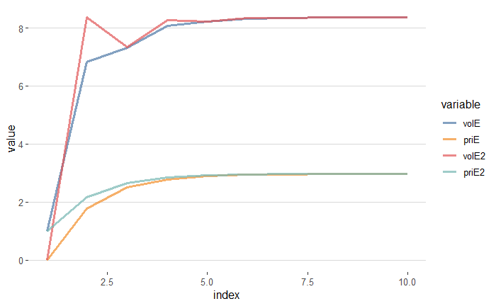

```r
sh1Melt <- melt(shocks1[,1:5], id.vars = "index")
ggplot(sh1Melt, aes(x = index, y = value, color = variable))+
  geom_line(size=1.1, alpha=0.7)+
  scale_color_tableau("Tableau 10")+
  theme_hc()+
  theme(legend.position = "right")
```

## Segunda Parte

### 1)Estimación

$y_{1t}=c_1+\beta_{11}y_{1t-1}+\beta_{12}y_{2t-1}+\delta_{11}y_{1t-2}+\delta_{12}y_{2t-2}+\epsilon{1t}$  
$y_{2t}=c_2+\beta_{21}y_{1t-1}+\beta_{22}y_{2t-1}+\delta_{21}y_{1t-2}+\delta_{22}y_{2t-2}+\epsilon{2t}$

```r
fit3 <- lm(cre.volume ~ cre.volumeL1 + cre.priceL1 + cre.volumeL2 + cre.priceL2, data = btc)
fit4 <- lm(cre.price ~ cre.volumeL1 + cre.priceL1 + cre.volumeL2 + cre.priceL2, btc)
summary(fit3)
```

```
Call:
lm(formula = cre.volume ~ cre.volumeL1 + cre.priceL1 + cre.volumeL2 +
    cre.priceL2, data = btc)

Residuals:
    Min      1Q  Median      3Q     Max
-64.943 -21.330  -9.125  18.051 109.067

Coefficients:
             Estimate Std. Error t value Pr(>|t|)
(Intercept)    8.1081     4.2241   1.919  0.05836 .
cre.volumeL1  -0.3766     0.1105  -3.407  0.00101 **
cre.priceL1    1.1602     0.4274   2.715  0.00807 **
cre.volumeL2  -0.2077     0.1104  -1.882  0.06339 .
cre.priceL2    0.6529     0.4358   1.498  0.13790
---
Signif. codes:  0 ‘***’ 0.001 ‘**’ 0.01 ‘*’ 0.05 ‘.’ 0.1 ‘ ’ 1

Residual standard error: 37.24 on 83 degrees of freedom
  (3 observations deleted due to missingness)
Multiple R-squared:  0.1771,    Adjusted R-squared:  0.1374
F-statistic: 4.465 on 4 and 83 DF,  p-value: 0.002563
```

```r
summary(fit4)
```

```
Call:
lm(formula = cre.price ~ cre.volumeL1 + cre.priceL1 + cre.volumeL2 +
    cre.priceL2, data = btc)

Residuals:
     Min       1Q   Median       3Q      Max
-18.5464  -7.5225   0.3805   6.4762  25.0977

Coefficients:
             Estimate Std. Error t value Pr(>|t|)
(Intercept)   1.46112    1.11220   1.314 0.192561
cre.volumeL1  0.01566    0.02910   0.538 0.592035
cre.priceL1   0.38783    0.11254   3.446 0.000894 ***
cre.volumeL2  0.02388    0.02906   0.822 0.413565
cre.priceL2  -0.02222    0.11476  -0.194 0.846936
---
Signif. codes:  0 ‘***’ 0.001 ‘**’ 0.01 ‘*’ 0.05 ‘.’ 0.1 ‘ ’ 1

Residual standard error: 9.805 on 83 degrees of freedom
  (3 observations deleted due to missingness)
Multiple R-squared:  0.1772,    Adjusted R-squared:  0.1375
F-statistic: 4.468 on 4 and 83 DF,  p-value: 0.002555
```

### 2) Quién afecta a quién?

$H_0:\beta_{12}=\delta_{12}=0$  
$\beta_{12}$ sí es significativa pero $\delta_{12}$ no lo es  
$H_0:\beta_{21}=\delta_{21}=0$  
Ni $\beta_{21}$ o $\delta_{21}$ son significativas

### 3) Respuesta a los shocks

#### a) Shocks del volumen

$y_{1T+1}= \sigma_1, y_{2T+1}=0$

```r
sum3 <- summary(fit3)
varFit3 <- sum3$sigma
##varFit3 <- sqrt(mean(sum3$residuals^2))
sum4 <- summary(fit4)
varFit4 <- sum4$sigma
##varFit4 <- sqrt(mean(sum4$residuals^2))
```

```r
shockSig2 <- data.frame(volE = c(tail(btc$cre.volume, 1), varFit3), priE = c(tail(btc$cre.price, 1), 0), volE2 = c(tail(btc$cre.volume, 1), 0), priE2 = c(tail(btc$cre.price, 1), varFit4), index = c(1, 2))
no <- 10
for (i in 1:no) {
shockSig2[i+2, "volE"] <- sum3$coeff["(Intercept)", 1] +
  sum3$coeff["cre.volumeL1", 1]*shockSig2$volE[i+1] + sum3$coeff["cre.priceL1", 1]*shockSig2$priE[i+1] +
  sum3$coeff["cre.volumeL2", 1]*shockSig2$volE[i] + sum3$coeff["cre.priceL2", 1]*shockSig2$priE[i]
shockSig2[i+2, "priE"] <- sum4$coeff["(Intercept)", 1] + sum4$coeff["cre.volumeL1", 1]*shockSig2$volE[i+1] + sum4$coeff["cre.priceL1", 1]*shockSig2$priE[i+1] + sum4$coeff["cre.volumeL2", 1]*shockSig2$volE[i] + sum4$coeff["cre.priceL2", 1]*shockSig2$priE[i]
shockSig2$index[i+2] <-i+2
}
```

#### b) Shocks del precio

$y_{1T+1}= 0, y_{2T+1}=\sigma_2$

```r
for (i in 1:no) {
shockSig2[i+2, "volE2"] <- sum3$coeff["(Intercept)", 1] + sum3$coeff["cre.volumeL1", 1]*shockSig2$volE2[i+1] + sum3$coeff["cre.priceL1", 1]*shockSig2$priE2[i+1] + sum3$coeff["cre.volumeL2", 1]*shockSig2$volE2[i] + sum3$coeff["cre.priceL2", 1]*shockSig2$priE2[i]
shockSig2[i+2, "priE2"] <- sum4$coeff["(Intercept)", 1] + sum4$coeff["cre.volumeL1", 1]*shockSig2$volE2[i+1] + sum4$coeff["cre.priceL1", 1]*shockSig2$priE2[i+1] + sum4$coeff["cre.volumeL2", 1]*shockSig2$volE2[i] + sum4$coeff["cre.priceL2", 1]*shockSig2$priE2[i]
}
```

#### Tabla de respuestas a los shocks

```r
  kable(shockSig2, escape = F) %>%
  kable_styling("hover", full_width = F) %>%
  column_spec(5, width = "4cm") %>%
  add_header_above(c("Shocks Volumen" = 2, "Shocks Precio" = 2, ""))
```

| Shocks Volumen volE | Shocks Volumen priE | Shocks Precio volE2 | Shocks Precio priE2 | index |
| --- | --- | --- | --- | --- |
| -17.314682 | 0.7375359 | -17.314682 | 0.7375359 | 1 |
| 37.238082 | 0.0000000 | 0.000000 | 9.8047830 | 2 |
| -1.838121 | 1.6141854 | 23.561716 | 4.8337523 | 3 |
| 2.938622 | 2.9477689 | 11.244742 | 3.4867938 | 4 |
| 11.857188 | 2.5705821 | 6.180967 | 3.4447848 | 5 |
| 7.939379 | 2.6483833 | 9.718083 | 3.0849634 | 6 |
| 7.406412 | 2.8386136 | 8.992848 | 2.8807813 | 7 |
| 8.692385 | 2.8087435 | 8.059463 | 2.8827163 | 8 |
| 8.408332 | 2.8003357 | 8.430543 | 2.8560691 | 9 |
| 8.218948 | 2.8240060 | 8.455007 | 2.8292081 | 10 |
| 8.371243 | 2.8236234 | 8.320155 | 2.8286287 | 11 |
| 8.368235 | 2.8208101 | 8.347649 | 2.8274739 | 12 |

### 4) Grafica los 4 resultados anteriors y analiza cuál efecto cruzado es mayor?

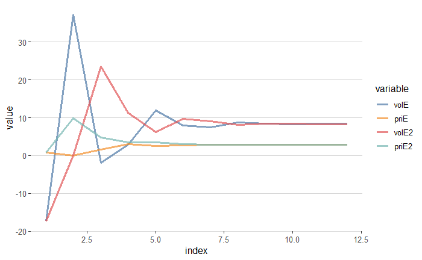

```r
shS2Melt <- melt(shockSig2[,1:5], id.vars = "index")
ggplot(shS2Melt, aes(x = index, y = value, color = variable))+
  geom_line(size=1.1, alpha=0.7)+
  scale_color_tableau("Tableau 10")+
  theme_hc()+
  theme(legend.position = "right")
```

### 5) Repite el 3 y 4

#### a)$y_{1T+1}= 1, y_{2T+1}= 0$

```r
shocks12 <- data.frame(volE = c(tail(btc$cre.volume, 1), 1), priE = c(tail(btc$cre.price, 1), 0), volE2 = c(tail(btc$cre.volume, 1), 0), priE2 = c(tail(btc$cre.price, 1), 1), index = c(1, 2))
no <- 10
for (i in 1:no) {
shocks12[i+2, "volE"] <- sum3$coeff["(Intercept)", 1] + sum3$coeff["cre.volumeL1", 1]*shocks12$volE[i+1] + sum3$coeff["cre.priceL1", 1]*shocks12$priE[i+1] + sum3$coeff["cre.volumeL2", 1]*shocks12$volE[i] + sum3$coeff["cre.priceL2", 1]*shocks12$priE[i]
shocks12[i+2, "priE"] <- sum4$coeff["(Intercept)", 1] + sum4$coeff["cre.volumeL1", 1]*shocks12$volE[i+1] + sum4$coeff["cre.priceL1", 1]*shocks12$priE[i+1] + sum4$coeff["cre.volumeL2", 1]*shocks12$volE[i] + sum4$coeff["cre.priceL2", 1]*shocks12$priE[i]
shocks12$index[i+2] <-i+2
}
```

```r
for (i in 1:no) {
shocks12[i+2, "volE2"] <- sum3$coeff["(Intercept)", 1] + sum3$coeff["cre.volumeL1", 1]*shocks12$volE2[i+1] + sum3$coeff["cre.priceL1", 1]*shocks12$priE2[i+1] + sum3$coeff["cre.volumeL2", 1]*shocks12$volE2[i] + sum3$coeff["cre.priceL2", 1]*shocks12$priE2[i]
shocks12[i+2, "priE2"] <- sum4$coeff["(Intercept)", 1] + sum4$coeff["cre.volumeL1", 1]*shocks12$volE2[i+1] + sum4$coeff["cre.priceL1", 1]*shocks12$priE2[i+1] + sum4$coeff["cre.volumeL2", 1]*shocks12$volE2[i] + sum4$coeff["cre.priceL2", 1]*shocks12$priE2[i]
}
```

#### Tabla de respuestas a los shocks

```r
  kable(shocks12, escape = F) %>%
  kable_styling("hover", full_width = F) %>%
  column_spec(5, width = "4cm") %>%
  add_header_above(c("Shocks Volumen" = 2, "Shocks Precio" = 2, ""))
```

| Shocks Volumen volE | Shocks Volumen priE | Shocks Precio volE2 | Shocks Precio priE2 | index |
| --- | --- | --- | --- | --- |
| -17.314682 | 0.7375359 | -17.314682 | 0.7375359 | 1 |
| 1.000000 | 0.0000000 | 0.000000 | 1.0000000 | 2 |
| 11.809362 | 1.0468382 | 13.346192 | 1.4190101 | 3 |
| 4.667453 | 2.0758844 | 5.381119 | 2.1981785 | 4 |
| 6.989434 | 2.5980740 | 6.786351 | 2.6851122 | 5 |
| 8.876128 | 2.6435015 | 8.985213 | 2.6884057 | 6 |
| 8.076966 | 2.7345128 | 8.186995 | 2.7468512 | 7 |
| 8.121316 | 2.8013505 | 8.100856 | 2.8094659 | 8 |
| 8.407574 | 2.8068567 | 8.409898 | 2.8120375 | 9 |
| 8.340585 | 2.8130478 | 8.355270 | 2.8144245 | 10 |
| 8.317135 | 2.8211149 | 8.316102 | 2.8218191 | 11 |
| 8.353283 | 2.8221388 | 8.352337 | 2.8227159 | 12 |

#### Gráfica

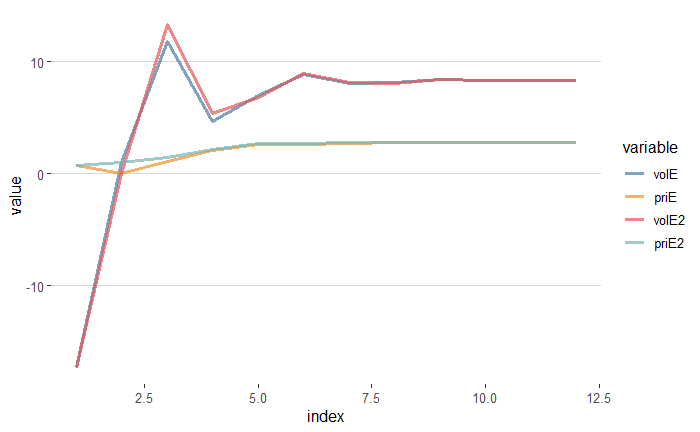

```r
sh12Melt <- melt(shocks12[,1:5], id.vars = "index")
ggplot(sh12Melt, aes(x = index, y = value, color = variable))+
  geom_line(size=1.1, alpha=0.7)+
  scale_color_tableau("Tableau 10")+
  theme_hc()+
  theme(legend.position = "right")
```

## Tercera Parte

### 1)Estimación

$y_{1t}=c_1+\beta_{11}y_{1t-1}+\beta_{12}y_{2t-1}+...+\delta_{11}y_{1t-5}+\delta_{12}y_{2t-5}+\epsilon{1t}$  
$y_{2t}=c_2+\beta_{21}y_{1t-1}+\beta_{22}y_{2t-1}+...+\delta_{21}y_{1t-5}+\delta_{22}y_{2t-5}+\epsilon{2t}$

```r
fit5 <- lm(cre.volume ~ cre.volumeL1 + cre.priceL1 + cre.volumeL2 + cre.priceL2 + cre.volumeL3 + cre.priceL3 + cre.volumeL4 + cre.priceL4 + cre.volumeL5 + cre.priceL5, data = btc)
fit6 <- lm(cre.price ~ cre.volumeL1 + cre.priceL1 + cre.volumeL2 + cre.priceL2 + cre.volumeL3 + cre.priceL3 + cre.volumeL4 + cre.priceL4 + cre.volumeL5 + cre.priceL5, data = btc)
summary(fit5)
```

```
Call:
lm(formula = cre.volume ~ cre.volumeL1 + cre.priceL1 + cre.volumeL2 +
    cre.priceL2 + cre.volumeL3 + cre.priceL3 + cre.volumeL4 +
    cre.priceL4 + cre.volumeL5 + cre.priceL5, data = btc)

Residuals:
    Min      1Q  Median      3Q     Max
-59.804 -20.798  -8.652  13.924 113.131

Coefficients:
             Estimate Std. Error t value Pr(>|t|)
(Intercept)   9.06250    4.78485   1.894  0.06213 .
cre.volumeL1 -0.41784    0.12226  -3.418  0.00103 **
cre.priceL1   1.29782    0.45408   2.858  0.00553 **
cre.volumeL2 -0.27000    0.13470  -2.005  0.04867 *
cre.priceL2   0.42180    0.48808   0.864  0.39027
cre.volumeL3 -0.10198    0.13844  -0.737  0.46364
cre.priceL3   0.66965    0.49068   1.365  0.17648
cre.volumeL4 -0.01096    0.13076  -0.084  0.93342
cre.priceL4  -0.25257    0.48696  -0.519  0.60555
cre.volumeL5 -0.00140    0.11883  -0.012  0.99063
cre.priceL5   0.07219    0.46659   0.155  0.87747
---
Signif. codes:  0 ‘***’ 0.001 ‘**’ 0.01 ‘*’ 0.05 ‘.’ 0.1 ‘ ’ 1

Residual standard error: 37.94 on 74 degrees of freedom
  (6 observations deleted due to missingness)
Multiple R-squared:  0.2087,    Adjusted R-squared:  0.1017
F-statistic: 1.951 on 10 and 74 DF,  p-value: 0.05127
```

```r
summary(fit6)
```

```
Call:
lm(formula = cre.price ~ cre.volumeL1 + cre.priceL1 + cre.volumeL2 +
    cre.priceL2 + cre.volumeL3 + cre.priceL3 + cre.volumeL4 +
    cre.priceL4 + cre.volumeL5 + cre.priceL5, data = btc)

Residuals:
     Min       1Q   Median       3Q      Max
-15.7284  -7.7976  -0.3963   7.4800  20.7043

Coefficients:
             Estimate Std. Error t value Pr(>|t|)
(Intercept)   1.10230    1.26537   0.871  0.38650
cre.volumeL1  0.03013    0.03233   0.932  0.35442
cre.priceL1   0.34036    0.12008   2.834  0.00592 **
cre.volumeL2  0.05242    0.03562   1.472  0.14534
cre.priceL2  -0.03462    0.12907  -0.268  0.78929
cre.volumeL3  0.03682    0.03661   1.006  0.31778
cre.priceL3  -0.08566    0.12976  -0.660  0.51123
cre.volumeL4  0.05375    0.03458   1.554  0.12438
cre.priceL4  -0.14690    0.12878  -1.141  0.25767
cre.volumeL5  0.04957    0.03142   1.577  0.11895
cre.priceL5  -0.14070    0.12339  -1.140  0.25786
---
Signif. codes:  0 ‘***’ 0.001 ‘**’ 0.01 ‘*’ 0.05 ‘.’ 0.1 ‘ ’ 1

Residual standard error: 10.03 on 74 degrees of freedom
  (6 observations deleted due to missingness)
Multiple R-squared:   0.23, Adjusted R-squared:  0.1259
F-statistic:  2.21 on 10 and 74 DF,  p-value: 0.02612
```

### 2) Quién afecta a quién?

$H_0:\beta_{12}=...=\delta_{12}=0$  
Solo el coeficiente de precio con lag 1 resultó significativo  
$H_0:\beta_{21}=...=\delta_{21}=0$  
Ningún coeficiente de volumen resultó significativo

### 3) Respuesta a los shocks

#### a) Shocks del volumen

$y_{1T+1}= \sigma_1, y_{2T+1}=0$

```r
sum5 <- summary(fit5)
varFit5 <- sum5$sigma
##varFit3 <- sqrt(mean(sum3$residuals^2))
sum6 <- summary(fit6)
varFit6 <- sum6$sigma
##varFit4 <- sqrt(mean(sum4$residuals^2))
```

```r
shockSig3 <- data.frame(volE = c(tail(btc$cre.volume, 4), varFit5), priE = c(tail(btc$cre.price, 4), 0), volE2 = c(tail(btc$cre.volume, 4), 0), priE2 = c(tail(btc$cre.price, 4), varFit6), index = c(1:5))
no <- 10
for (i in 1:no) {
shockSig3[i+5, "volE"] <- sum5$coeff["(Intercept)", 1] +
  sum5$coeff["cre.volumeL1", 1]*shockSig3$volE[i+4] + sum5$coeff["cre.priceL1", 1]*shockSig3$priE[i+4] +
  sum5$coeff["cre.volumeL2", 1]*shockSig3$volE[i+3] + sum5$coeff["cre.priceL2", 1]*shockSig3$priE[i+3] +
  sum5$coeff["cre.volumeL3", 1]*shockSig3$volE[i+2] + sum5$coeff["cre.priceL3", 1]*shockSig3$priE[i+2] +
  sum5$coeff["cre.volumeL4", 1]*shockSig3$volE[i+1] + sum5$coeff["cre.priceL4", 1]*shockSig3$priE[i+1] +
  sum5$coeff["cre.volumeL5", 1]*shockSig3$volE[i] + sum5$coeff["cre.priceL5", 1]*shockSig3$priE[i]

shockSig3[i+5, "priE"] <- sum6$coeff["(Intercept)", 1] +
  sum6$coeff["cre.volumeL1", 1]*shockSig3$volE[i+4] + sum6$coeff["cre.priceL1", 1]*shockSig3$priE[i+4] +
  sum6$coeff["cre.volumeL2", 1]*shockSig3$volE[i+3] + sum6$coeff["cre.priceL2", 1]*shockSig3$priE[i+3] +
  sum6$coeff["cre.volumeL3", 1]*shockSig3$volE[i+2] + sum6$coeff["cre.priceL3", 1]*shockSig3$priE[i+2] +
  sum6$coeff["cre.volumeL4", 1]*shockSig3$volE[i+1] + sum6$coeff["cre.priceL4", 1]*shockSig3$priE[i+1] +
  sum6$coeff["cre.volumeL5", 1]*shockSig3$volE[i] + sum6$coeff["cre.priceL5", 1]*shockSig3$priE[i]
shockSig3$index[i+5] <-i+5
}
```

#### b) Shocks del precio

$y_{1T+1}= 0, y_{2T+1}=\sigma_2$

```r
for (i in 1:no) {
shockSig3[i+5, "volE2"] <- sum5$coeff["(Intercept)", 1] +
  sum5$coeff["cre.volumeL1", 1]*shockSig3$volE2[i+4] + sum5$coeff["cre.priceL1", 1]*shockSig3$priE2[i+4] +
  sum5$coeff["cre.volumeL2", 1]*shockSig3$volE2[i+3] + sum5$coeff["cre.priceL2", 1]*shockSig3$priE2[i+3] +
  sum5$coeff["cre.volumeL3", 1]*shockSig3$volE2[i+2] + sum5$coeff["cre.priceL3", 1]*shockSig3$priE2[i+2] +
  sum5$coeff["cre.volumeL4", 1]*shockSig3$volE2[i+1] + sum5$coeff["cre.priceL4", 1]*shockSig3$priE2[i+1] +
  sum5$coeff["cre.volumeL5", 1]*shockSig3$volE2[i] + sum5$coeff["cre.priceL5", 1]*shockSig3$priE2[i]

shockSig3[i+5, "priE2"] <- sum6$coeff["(Intercept)", 1] +
  sum6$coeff["cre.volumeL1", 1]*shockSig3$volE2[i+4] + sum6$coeff["cre.priceL1", 1]*shockSig3$priE2[i+4] +
  sum6$coeff["cre.volumeL2", 1]*shockSig3$volE2[i+3] + sum6$coeff["cre.priceL2", 1]*shockSig3$priE2[i+3] +
  sum6$coeff["cre.volumeL3", 1]*shockSig3$volE2[i+2] + sum6$coeff["cre.priceL3", 1]*shockSig3$priE2[i+2] +
  sum6$coeff["cre.volumeL4", 1]*shockSig3$volE2[i+1] + sum6$coeff["cre.priceL4", 1]*shockSig3$priE2[i+1] +
  sum6$coeff["cre.volumeL5", 1]*shockSig3$volE2[i] + sum6$coeff["cre.priceL5", 1]*shockSig3$priE2[i]
}
```

#### Tabla de respuestas a los shocks

```r
  kable(shockSig3, escape = F) %>%
  kable_styling("hover", full_width = F) %>%
  column_spec(5, width = "4cm") %>%
  add_header_above(c("Shocks Volumen" = 2, "Shocks Precio" = 2, ""))
```

| Shocks Volumen volE | Shocks Volumen priE | Shocks Precio volE2 | Shocks Precio priE2 | index |
| --- | --- | --- | --- | --- |
| 12.802086 | -3.3945776 | 12.802086 | -3.3945776 | 1 |
| -43.162048 | -5.1253596 | -43.162048 | -5.1253596 | 2 |
| 58.031917 | 1.5108751 | 58.031917 | 1.5108751 | 3 |
| -17.314682 | 0.7375359 | -17.314682 | 0.7375359 | 4 |
| 37.937573 | 0.0000000 | 0.000000 | 10.0326859 | 5 |
| -5.205039 | 2.8648062 | 23.667317 | 5.1364501 | 6 |
| 5.644570 | 4.6873847 | 11.003823 | 3.9943660 | 7 |
| 11.563467 | 5.5177655 | 12.174760 | 4.6219364 | 8 |
| 13.955892 | 4.1023550 | 7.257155 | 1.4764817 | 9 |
| 9.604237 | 4.3205287 | 7.328842 | 1.4707579 | 10 |
| 10.103052 | 2.3586836 | 7.634000 | 2.6606211 | 11 |
| 7.265437 | 2.1571843 | 7.188069 | 2.6708069 | 12 |
| 8.200217 | 2.4313228 | 8.687965 | 2.8062631 | 13 |
| 7.369043 | 2.6492165 | 8.907899 | 2.9866300 | 14 |
| 8.528690 | 2.7192132 | 8.450170 | 2.9572640 | 15 |

### 4) Grafica los 4 resultados anteriors y analiza cuál efecto cruzado es mayor?

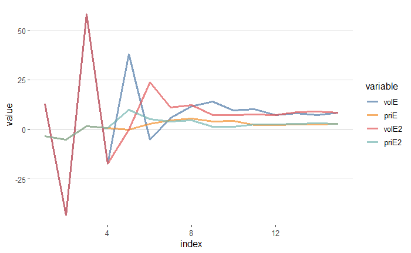

```r
shS3Melt <- melt(shockSig3[,1:5], id.vars = "index")
ggplot(shS3Melt, aes(x = index, y = value, color = variable))+
  geom_line(size=1.1, alpha=0.7)+
  scale_color_tableau("Tableau 10")+
  theme_hc()+
  theme(legend.position = "right")
```

### 5) Repite el 3 y 4

#### a)$y_{1T+1}= 1, y_{2T+1}= 0$

```r
shocks13 <- data.frame(volE = c(tail(btc$cre.volume, 4), 1), priE = c(tail(btc$cre.price, 4), 0), volE2 = c(tail(btc$cre.volume, 4), 0), priE2 = c(tail(btc$cre.price, 4), 1), index = c(1:5))
no <- 10
for (i in 1:no) {
shocks13[i+5, "volE"] <- sum5$coeff["(Intercept)", 1] +
  sum5$coeff["cre.volumeL1", 1]*shocks13$volE[i+4] + sum5$coeff["cre.priceL1", 1]*shocks13$priE[i+4] +
  sum5$coeff["cre.volumeL2", 1]*shocks13$volE[i+3] + sum5$coeff["cre.priceL2", 1]*shocks13$priE[i+3] +
  sum5$coeff["cre.volumeL3", 1]*shocks13$volE[i+2] + sum5$coeff["cre.priceL3", 1]*shocks13$priE[i+2] +
  sum5$coeff["cre.volumeL4", 1]*shocks13$volE[i+1] + sum5$coeff["cre.priceL4", 1]*shocks13$priE[i+1] +
  sum5$coeff["cre.volumeL5", 1]*shocks13$volE[i] + sum5$coeff["cre.priceL5", 1]*shocks13$priE[i]

shocks13[i+5, "priE"] <- sum6$coeff["(Intercept)", 1] +
  sum6$coeff["cre.volumeL1", 1]*shocks13$volE[i+4] + sum6$coeff["cre.priceL1", 1]*shocks13$priE[i+4] +
  sum6$coeff["cre.volumeL2", 1]*shocks13$volE[i+3] + sum6$coeff["cre.priceL2", 1]*shocks13$priE[i+3] +
  sum6$coeff["cre.volumeL3", 1]*shocks13$volE[i+2] + sum6$coeff["cre.priceL3", 1]*shocks13$priE[i+2] +
  sum6$coeff["cre.volumeL4", 1]*shocks13$volE[i+1] + sum6$coeff["cre.priceL4", 1]*shocks13$priE[i+1] +
  sum6$coeff["cre.volumeL5", 1]*shocks13$volE[i] + sum6$coeff["cre.priceL5", 1]*shocks13$priE[i]
shocks13$index[i+5] <-i+5
}
```

```r
for (i in 1:no) {
shocks13[i+5, "volE2"] <- sum5$coeff["(Intercept)", 1] +
  sum5$coeff["cre.volumeL1", 1]*shocks13$volE2[i+4] + sum5$coeff["cre.priceL1", 1]*shocks13$priE2[i+4] +
  sum5$coeff["cre.volumeL2", 1]*shocks13$volE2[i+3] + sum5$coeff["cre.priceL2", 1]*shocks13$priE2[i+3] +
  sum5$coeff["cre.volumeL3", 1]*shocks13$volE2[i+2] + sum5$coeff["cre.priceL3", 1]*shocks13$priE2[i+2] +
  sum5$coeff["cre.volumeL4", 1]*shocks13$volE2[i+1] + sum5$coeff["cre.priceL4", 1]*shocks13$priE2[i+1] +
  sum5$coeff["cre.volumeL5", 1]*shocks13$volE2[i] + sum5$coeff["cre.priceL5", 1]*shocks13$priE2[i]

shocks13[i+5, "priE2"] <- sum6$coeff["(Intercept)", 1] +
  sum6$coeff["cre.volumeL1", 1]*shocks13$volE2[i+4] + sum6$coeff["cre.priceL1", 1]*shocks13$priE2[i+4] +
  sum6$coeff["cre.volumeL2", 1]*shocks13$volE2[i+3] + sum6$coeff["cre.priceL2", 1]*shocks13$priE2[i+3] +
  sum6$coeff["cre.volumeL3", 1]*shocks13$volE2[i+2] + sum6$coeff["cre.priceL3", 1]*shocks13$priE2[i+2] +
  sum6$coeff["cre.volumeL4", 1]*shocks13$volE2[i+1] + sum6$coeff["cre.priceL4", 1]*shocks13$priE2[i+1] +
  sum6$coeff["cre.volumeL5", 1]*shocks13$volE2[i] + sum6$coeff["cre.priceL5", 1]*shocks13$priE2[i]
}
```

#### Tabla de respuestas a los shocks

```r
  kable(shocks13, escape = F) %>%
  kable_styling("hover", full_width = F) %>%
  column_spec(5, width = "4cm") %>%
  add_header_above(c("Shocks Volumen" = 2, "Shocks Precio" = 2, ""))
```

| Shocks Volumen volE | Shocks Volumen priE | Shocks Precio volE2 | Shocks Precio priE2 | index |
| --- | --- | --- | --- | --- |
| 12.802086 | -3.3945776 | 12.802086 | -3.3945776 | 1 |
| -43.162048 | -5.1253596 | -43.162048 | -5.1253596 | 2 |
| 58.031917 | 1.5108751 | 58.031917 | 1.5108751 | 3 |
| -17.314682 | 0.7375359 | -17.314682 | 0.7375359 | 4 |
| 1.000000 | 0.0000000 | 0.000000 | 1.0000000 | 5 |
| 10.228828 | 1.7518858 | 11.944488 | 2.0621129 | 6 |
| 7.724566 | 2.8372464 | 8.102122 | 2.9074857 | 7 |
| 7.423671 | 4.4381862 | 7.796328 | 4.4301874 | 8 |
| 11.028189 | 2.4615450 | 10.580953 | 2.3233660 | 9 |
| 8.072974 | 2.8913310 | 7.961480 | 2.7149008 | 10 |
| 9.028211 | 2.9746930 | 8.863046 | 2.9584029 | 11 |
| 7.706016 | 2.6358995 | 7.665129 | 2.6510472 | 12 |
| 8.760929 | 2.6262498 | 8.767323 | 2.6489437 | 13 |
| 8.256232 | 2.8600081 | 8.342811 | 2.8777669 | 14 |
| 8.393198 | 2.7924691 | 8.395574 | 2.8106804 | 15 |

#### Gráfica

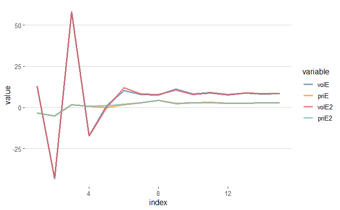

```r
sh13Melt <- melt(shocks13[,1:5], id.vars = "index")
ggplot(sh13Melt, aes(x = index, y = value, color = variable))+
  geom_line(size=1.1, alpha=0.7)+
  scale_color_tableau("Tableau 10")+
  theme_hc()+
  theme(legend.position = "right")
```